# Interpreting the Effects of COVID-19 on the University of Maryland

**by Allen Tu, Joshua Blume, Zach Mazer** – July 21, 2020  
[Data](https://github.com/nytimes/covid-19-dat) by the New York Times

On March 18, 2020, The University of Maryland began operating online due to the coronavirus pandemic. Since then, the country has experienced numerous overlapping responses from federal, state and local governments in an effort to prevent and contain the spread of COVID-19. The state of Maryland, which has spent several months under evolving lockdown orders, is now allowing limited on-campus courses at universities for the Fall semester. This leaves many students considering whether it is safe to be on campus and if they should live in residence halls and nearby apartments.

This tutorial uses the following imports to scrape, process, and analyze data.

```python
import pandas as pd
import numpy as np
import matplotlib.pyplot as plt
from sklearn.linear_model import LinearRegression
from sklearn.feature_selection import f_regression
from sklearn.metrics import r2_score
# Suppress SettingWithoutCopy warning.
import warnings
warnings.simplefilter('ignore')
import os
```

## Case Data on Coronavirus

Considering the uncertainty of this period, we want to demonstrate the trends of coronavirus in the country and what we could expect in Maryland during the Fall semester with the information currently available to us. We'll primarily be using the coronavirus data compiled by the New York Times, then processing it to demonstrate various facts about the state of the pandemic.

The first thing we'll do is read in the data from the ['us-counties.csv'](https://raw.githubusercontent.com/nytimes/covid-19-data/master/us-counties.csv) file in the [New York Times COVID-19 GitHub](https://github.com/nytimes/covid-19-data). This dataset tracks the number of COVID-19 cases and deaths across US counties for each day since January 21, 2020.

```python
# Read NYT us-counties dataset.
url = 'https://raw.githubusercontent.com/nytimes/covid-19-data/master/us-counties.csv'
covid = pd.read_csv(url, error_bad_lines=False)
covid
```

|  | date | county | state | fips | cases | deaths |
| --- | --- | --- | --- | --- | --- | --- |
| 0 | 2020-01-21 | Snohomish | Washington | 53061.0 | 1 | 0 |
| 1 | 2020-01-22 | Snohomish | Washington | 53061.0 | 1 | 0 |
| 2 | 2020-01-23 | Snohomish | Washington | 53061.0 | 1 | 0 |
| 3 | 2020-01-24 | Cook | Illinois | 17031.0 | 1 | 0 |
| 4 | 2020-01-24 | Snohomish | Washington | 53061.0 | 1 | 0 |
| ... | ... | ... | ... | ... | ... | ... |
| 353563 | 2020-07-20 | Sweetwater | Wyoming | 56037.0 | 181 | 2 |
| 353564 | 2020-07-20 | Teton | Wyoming | 56039.0 | 223 | 1 |
| 353565 | 2020-07-20 | Uinta | Wyoming | 56041.0 | 222 | 0 |
| 353566 | 2020-07-20 | Washakie | Wyoming | 56043.0 | 43 | 5 |
| 353567 | 2020-07-20 | Weston | Wyoming | 56045.0 | 4 | 0 |

353568 rows × 6 columns

As one can see from the sample above, the data lists the instances recorded by state governments in which someone has tested positive for coronavirus. In order to make this data easier to work with, we merged the county name with the state name in order to clearly distinguish counties in different states with the same name (ex. Orange County, California and Orange County, Florida) and dropped the fips identifier because it is not used by every county.

```python
# Add state to county column because some counties share a name.
# State column is retained because it is useful for comparison.
covid['county'] = covid['county'].str.cat(covid['state'],sep=", ")
# Drop fips column because other datasets do not use it as an identifier.
covid.drop(['fips'], axis=1, inplace=True)

covid
```

|  | date | county | state | cases | deaths |
| --- | --- | --- | --- | --- | --- |
| 0 | 2020-01-21 | Snohomish, Washington | Washington | 1 | 0 |
| 1 | 2020-01-22 | Snohomish, Washington | Washington | 1 | 0 |
| 2 | 2020-01-23 | Snohomish, Washington | Washington | 1 | 0 |
| 3 | 2020-01-24 | Cook, Illinois | Illinois | 1 | 0 |
| 4 | 2020-01-24 | Snohomish, Washington | Washington | 1 | 0 |
| ... | ... | ... | ... | ... | ... |
| 353563 | 2020-07-20 | Sweetwater, Wyoming | Wyoming | 181 | 2 |
| 353564 | 2020-07-20 | Teton, Wyoming | Wyoming | 223 | 1 |
| 353565 | 2020-07-20 | Uinta, Wyoming | Wyoming | 222 | 0 |
| 353566 | 2020-07-20 | Washakie, Wyoming | Wyoming | 43 | 5 |
| 353567 | 2020-07-20 | Weston, Wyoming | Wyoming | 4 | 0 |

353568 rows × 5 columns

The resulting dataframe contains all the coronavirus data used in this tutorial.

## Visualizing the Pandemic

Coronavirus is surging throughout the United States. We created visualizations tracking the total documented cases and deaths counts across the entire United States over time to better understand the magnitude of the disease's spread.

The coronavirus was first identified in the United States on January 20 in Snohomish County, Washington State; the NYT dataset and these plots begin on the next day, January 21. We obtained these figures by grouping the entries by date and calculating the sum of cases and deaths across all counties on each day.

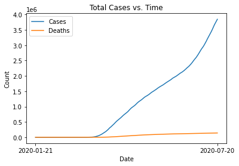

```
Total Cases: 3844886
```

```python
# Calculate total number of cases and deaths for each day.
cases = covid.groupby('date', as_index=False)[['cases']].sum()
deaths = covid.groupby('date', as_index=False)[['deaths']].sum()

# Plot cases and deaths on a single line chart.
plt.plot(cases['date'], cases['cases'], label='Cases')
plt.plot(deaths['date'], deaths['deaths'], label='Deaths')
plt.title('Total Cases vs. Time')
plt.xlabel('Date')
plt.xticks([covid.date.min(), covid.date.max()])
plt.ylabel('Count')
plt.legend(loc='upper left')
plt.show()

# Select the most current data.
covid_current = covid.loc[covid['date'] == covid.date.max()]

# Print cumulative data.
total_cases = covid_current.cases.sum()
print('Total Cases: ' + str(total_cases))
```

Efforts, such as the closing of public areas and the encouragement of social distancing, to slow the spread of the disease probably prevented hundreds of thousands of additional cases during the first months of the pandemic. However, despite the rapidly growing numbers, many states attempted to reopen. The gradual exponential curve that began around the end of June is most likely a result of these decisions and, now, approximately 60,000 to 70,000 new cases are reported each day -- more than double the amount in prior months. The current total is around 3.85 million and cases are still climbing steeply.

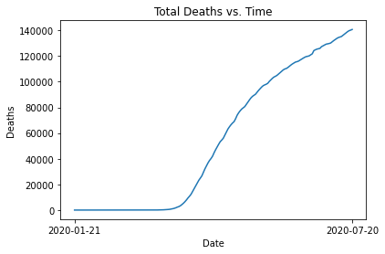

```
Total Deaths: 140724
Death Rate: 0.03660030492451532
```

```python
# Plot deaths on a line chart.
plt.plot(deaths['date'], deaths['deaths'])
plt.title('Total Deaths vs. Time')
plt.xlabel('Date')
plt.xticks([covid.date.min(), covid.date.max()])
plt.ylabel('Deaths')
plt.show()

# Print cumulative data.
total_deaths = covid_current.deaths.sum()
death_rate = total_deaths / total_cases
print('Total Deaths: ' + str(total_deaths))
print('Death Rate: ' + str(death_rate))
```

It is obvious, by examining the Cases vs. Time plot, that deaths make up only a small percentage of all coronavirus cases. However, the deaths of over 140,000 Americans are anything but insignificant.

The death toll has followed a roughly logarithmic trend since the first death from complications attributed to COVID-19 was recorded on February 29 in King County, Washington State. As treatment becomes more effective and a vaccine is eventually developed, the distribution is expected to gradually level out and, ultimately, plateau.

## Modeling the Pandemic by State

Different areas of the United States have been impacted by the coronavirus to various degrees. As demonstrated by the bar chart below, the total cases for U.S. states are vastly different from each other, even for those that are adjacent to each other.

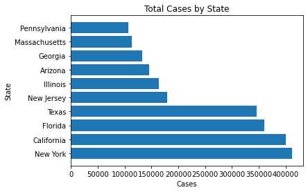

```python
# Creates top 10 bar chart for county or state.
def top_10(measure):
    bar_chart = covid_current.groupby(measure, as_index=False)[['cases']].sum()
    bar_chart = bar_chart.sort_values(by='cases', ascending=False)
    bar_chart = bar_chart.head(10)
    bar_chart.describe()
    # Create bar chart.
    plt.barh(bar_chart[measure], bar_chart['cases'])
    plt.title('Total Cases by ' + measure.capitalize())
    plt.xlabel('Cases')
    plt.ylabel(measure.capitalize())
    plt.show()

# Top 10 cases bar chart for county.
top_10('state')
```

Exploring the relationship between cases and state population means that we need the total case count for each state. The entries in the COVID-19 dataset are by county, so we group the COVID-19 dataframe by state, calculate the sum of the cases of each group, and then create a dataframe with the totals.

The result is a dataframe with each state and its corresponding total case count.

```python
# D.C., Guam, Northern Mariana Islands, Puerto Rico, and Virign Islands account for the 5 extra rows.
groups = covid.groupby('state')
state_list = []
s_names = []
for state, g in groups:
    state_list.append(g)
    s_names.append(state)

# Calculate total cases for each state.
cases = {}
for i, state in enumerate(state_list):
    total = state['cases'].sum()
    cases[s_names[i]] = total
# Create dataframe for total cases by state.
state_totals = pd.DataFrame(list(cases.items()),columns = ['state','cases'])
state_totals.head()
```

|  | state | cases |
| --- | --- | --- |
| 0 | Alabama | 2351391 |
| 1 | Alaska | 78216 |
| 2 | Arizona | 4180824 |
| 3 | Arkansas | 1157337 |
| 4 | California | 14661182 |

The other data we need for this comparison is the total population of each state. The website [Infoplease.com](https://www.infoplease.com/us/states/state-population-by-rank) displays the July 2019 Estimate and Percent of Total population for all 50 states and the District of Columbia. We scrape the html from the website using pandas and then process the table into a dataframe.

```python
# Scrape population data by state.
pop_list = pd.read_html("https://www.infoplease.com/us/states/state-population-by-rank")
# Create dataframe for population by state.
pop_df = pop_list[0]
pop_df.columns = ['rank', 'state', 'pop', 'percent of total pop']

pop_df.head()
```

|  | rank | state | pop | percent of total pop |
| --- | --- | --- | --- | --- |
| 0 | 1 | California | 39512223 | 11.91% |
| 1 | 2 | Texas | 28995881 | 8.74% |
| 2 | 3 | Florida | 21477737 | 6.47% |
| 3 | 4 | New York | 19453561 | 5.86% |
| 4 | 5 | Illinois | 12671821 | 3.86% |

Now, we combine the population and total cases of each state into a single dataframe and drop all other columns.

```python
# Merge dataframes into a dataframe for population and cases by state.
covid_pop = pd.merge(left=pop_df, right=state_totals, left_on='state', right_on='state')
covid_pop = covid_pop.drop(columns=['rank', 'percent of total pop'])

covid_pop
```

|  | state | pop | cases |
| --- | --- | --- | --- |
| 0 | California | 39512223 | 14661182 |
| 1 | Texas | 28995881 | 10184301 |
| 2 | Florida | 21477737 | 9849214 |
| 3 | New York | 19453561 | 37411374 |
| 4 | Illinois | 12671821 | 10767376 |
| 5 | Pennsylvania | 12801989 | 7334872 |
| 6 | Ohio | 11689100 | 3705398 |
| 7 | Georgia | 10617423 | 5424042 |
| 8 | North Carolina | 10488084 | 3801740 |
| 9 | Michigan | 9986857 | 5926611 |
| 10 | New Jersey | 8882190 | 15304897 |
| 11 | Virginia | 8535519 | 4200039 |
| 12 | Washington | 7614893 | 2651120 |
| 13 | Arizona | 7278717 | 4180824 |
| 14 | Massachusetts | 6949503 | 8985921 |
| 15 | Tennessee | 6833174 | 2892687 |
| 16 | Indiana | 6732219 | 3446364 |
| 17 | Missouri | 6137428 | 1574894 |
| 18 | Maryland | 6045680 | 4858286 |
| 19 | Wisconsin | 5822434 | 2052627 |
| 20 | Colorado | 5758736 | 2559401 |
| 21 | Minnesota | 5639632 | 2292414 |
| 22 | South Carolina | 5148714 | 2110524 |
| 23 | Alabama | 4903185 | 2351391 |
| 24 | Louisiana | 4648794 | 4670736 |
| 25 | Kentucky | 4467673 | 1091654 |
| 26 | Oregon | 4217737 | 583723 |
| 27 | Oklahoma | 3956971 | 902121 |
| 28 | Connecticut | 3565287 | 3900376 |
| 29 | Utah | 3205958 | 1346040 |
| 30 | Iowa | 3155070 | 1946864 |
| 31 | Nevada | 3080156 | 1225902 |
| 32 | Arkansas | 3017825 | 1157337 |
| 33 | Mississippi | 2976149 | 1780220 |
| 34 | Kansas | 2913314 | 1033647 |
| 35 | New Mexico | 2096829 | 821629 |
| 36 | Nebraska | 1934408 | 1280743 |
| 37 | West Virginia | 1792147 | 221790 |
| 38 | Idaho | 1787065 | 450565 |
| 39 | Hawaii | 1415872 | 81150 |
| 40 | New Hampshire | 1359711 | 428112 |
| 41 | Maine | 1344212 | 230837 |
| 42 | Montana | 1068778 | 81529 |
| 43 | Rhode Island | 1059361 | 1331749 |
| 44 | Delaware | 973764 | 864462 |
| 45 | South Dakota | 884659 | 481745 |
| 46 | North Dakota | 762062 | 251940 |
| 47 | Alaska | 731545 | 78216 |
| 48 | Vermont | 623989 | 111268 |
| 49 | Wyoming | 578759 | 104889 |

We graph the total cases across total population for each U.S. state in a scatterplot to visualize the relationship between case count and population. The distribution appears to be roughly linear, so we also fit linear regression line using scikit-learn and overlay it on the plot.

Scikit-learn is also used to calculate the $p$-value of the distribution and $r^2$ score of the model. The null hypothesis of the significance test is that there is no statistically significant relationship between the total number of COVID-19 cases in a state and its population.

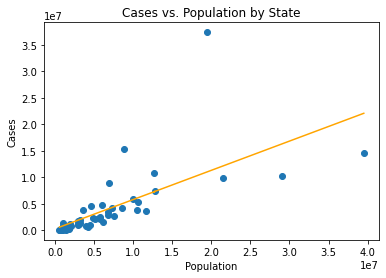

```
Predicted Cases = 0.5523015126440362 * Population + 281112.84374374105
r2 score: 0.45226522563566884
p-value: 8.852761150461485e-08
```

```python
# Create linear regression model.
pop = covid_pop['pop'].values.reshape(-1,1)
cases = covid_pop['cases'].values.reshape(-1,1)
model = LinearRegression()
model.fit(pop, cases)
predicted = model.predict(pop)
# Calculate p-value.A small p-value indicates strong evidence against the null hypothesis.
F = f_regression(pop, cases, center=True)

# Create scatterplot for cases across population by state.
plt.plot(pop,predicted, color='orange')
plt.scatter(pop, cases)
plt.title("Cases vs. Population by State")
plt.xlabel('Population')
plt.ylabel('Cases')
plt.show()
# Print fitted model.
print('Predicted Cases = ' + str(model.coef_[0][0]) + ' * Population + ' + str(model.intercept_[0]))
print('r2 score: ' + str(r2_score(cases, predicted)))
print('p-value: '+ str(F[1][0]))
```

The $p$-value is 8.85e-08, which is less than the accepted threshold of 0.05. Therefore, we reject the null hypothesis: there is a highly statistically significant relationship between the total number of COVID-19 cases in a state and its population.

However, the $r^2$ score is a low 0.452, indicating that linear regression model is not a good representation of the true relationship between cases and population. Possible explanations for the low goodness of fit are that there are not enough data points and that the measures vary too widely for each state.

## Modeling the Pandemic by County

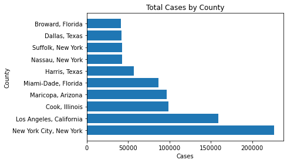

```python
# Top 10 cases bar chart for county.
top_10('county')
```

Measuring cases and population across counties attempts to address both of these problems. Similar to the states bar chart, the three counties with the most COVID-19 cases are also where the three most populous cities (New York, Los Angeles, and Chicago, respectively) in the United States are located.

The population of each county is needed to create another linear regression model. [County Population Totals](https://www.census.gov/data/datasets/time-series/demo/popest/2010s-counties-total.html) are estimated each year by the U.S. Census Bureau. We will use the 2019 estimates because the 2020 Census has not been released yet. To access the data, we download the ['co-est2019-annres.xlsx'](https://www2.census.gov/programs-surveys/popest/tables/2010-2019/counties/totals/co-est2019-annres.xlsx) file, which contains the population estimates for each US county, from the U.S. Census Bureau's website. The top two rows of the downloaded .xlsx file are a heading. We removed the heading so the .xlsx file is compatible with pandas. The resulting .xlsx file is read to create a dataframe that contains the county population totals for every year since 2010.

```python
# Read census from .xlsx.
census = pd.read_excel('co-est2019-annres.xlsx')
census
```

|  | County | 2010 | 2011 | 2012 | 2013 | 2014 | 2015 | 2016 | 2017 | 2018 | 2019 |
| --- | --- | --- | --- | --- | --- | --- | --- | --- | --- | --- | --- |
| 0 | .Autauga County, Alabama | 54773.0 | 55227.0 | 54954.0 | 54727.0 | 54893.0 | 54864.0 | 55243.0 | 55390.0 | 55533.0 | 55869.0 |
| 1 | .Baldwin County, Alabama | 183112.0 | 186558.0 | 190145.0 | 194885.0 | 199183.0 | 202939.0 | 207601.0 | 212521.0 | 217855.0 | 223234.0 |
| 2 | .Barbour County, Alabama | 27327.0 | 27341.0 | 27169.0 | 26937.0 | 26755.0 | 26283.0 | 25806.0 | 25157.0 | 24872.0 | 24686.0 |
| 3 | .Bibb County, Alabama | 22870.0 | 22745.0 | 22667.0 | 22521.0 | 22553.0 | 22566.0 | 22586.0 | 22550.0 | 22367.0 | 22394.0 |
| 4 | .Blount County, Alabama | 57376.0 | 57560.0 | 57580.0 | 57619.0 | 57526.0 | 57526.0 | 57494.0 | 57787.0 | 57771.0 | 57826.0 |
| ... | ... | ... | ... | ... | ... | ... | ... | ... | ... | ... | ... |
| 3143 | Note: The 6,222 people in Bedford city, Virgin... | NaN | NaN | NaN | NaN | NaN | NaN | NaN | NaN | NaN | NaN |
| 3144 | Suggested Citation: | NaN | NaN | NaN | NaN | NaN | NaN | NaN | NaN | NaN | NaN |
| 3145 | Annual Estimates of the Resident Population fo... | NaN | NaN | NaN | NaN | NaN | NaN | NaN | NaN | NaN | NaN |
| 3146 | Source: U.S. Census Bureau, Population Division | NaN | NaN | NaN | NaN | NaN | NaN | NaN | NaN | NaN | NaN |
| 3147 | Release Date: March 2020 | NaN | NaN | NaN | NaN | NaN | NaN | NaN | NaN | NaN | NaN |

3148 rows × 11 columns

The census data must be preprocessed because it is not compatible with the COVID-19 data in its current form. We drop the bottom columns because all of them are footnotes that are not useful to our analysis. Then, we use string functions to process 'County' column into 'county' and 'state' columns that match the format of the COVID-19 dataset.

```python
# Drop NaN columns (all footnotes).
census = census.dropna()

# Format County to match the COVID Dataset.
census.rename(columns={'County':'county'}, inplace=True)
census['county'] = census['county'].str.replace('.','')
census['county'] = census['county'].str.replace(' County','')
# Add state column to match the COVID Dataset.
census['state'] = census['county'].str.partition(', ')[2]
# Reorder columns.
census = census[['county','state',2010,2011,2012,2013,2014,2015,2016,2017,2018,2019]]

census
```

|  | county | state | 2010 | 2011 | 2012 | 2013 | 2014 | 2015 | 2016 | 2017 | 2018 | 2019 |
| --- | --- | --- | --- | --- | --- | --- | --- | --- | --- | --- | --- | --- |
| 0 | Autauga, Alabama | Alabama | 54773.0 | 55227.0 | 54954.0 | 54727.0 | 54893.0 | 54864.0 | 55243.0 | 55390.0 | 55533.0 | 55869.0 |
| 1 | Baldwin, Alabama | Alabama | 183112.0 | 186558.0 | 190145.0 | 194885.0 | 199183.0 | 202939.0 | 207601.0 | 212521.0 | 217855.0 | 223234.0 |
| 2 | Barbour, Alabama | Alabama | 27327.0 | 27341.0 | 27169.0 | 26937.0 | 26755.0 | 26283.0 | 25806.0 | 25157.0 | 24872.0 | 24686.0 |
| 3 | Bibb, Alabama | Alabama | 22870.0 | 22745.0 | 22667.0 | 22521.0 | 22553.0 | 22566.0 | 22586.0 | 22550.0 | 22367.0 | 22394.0 |
| 4 | Blount, Alabama | Alabama | 57376.0 | 57560.0 | 57580.0 | 57619.0 | 57526.0 | 57526.0 | 57494.0 | 57787.0 | 57771.0 | 57826.0 |
| ... | ... | ... | ... | ... | ... | ... | ... | ... | ... | ... | ... | ... |
| 3137 | Sweetwater, Wyoming | Wyoming | 43574.0 | 43986.0 | 45002.0 | 45157.0 | 44948.0 | 44719.0 | 44222.0 | 43464.0 | 42858.0 | 42343.0 |
| 3138 | Teton, Wyoming | Wyoming | 21296.0 | 21414.0 | 21624.0 | 22315.0 | 22773.0 | 23047.0 | 23234.0 | 23384.0 | 23269.0 | 23464.0 |
| 3139 | Uinta, Wyoming | Wyoming | 21089.0 | 20896.0 | 20996.0 | 20951.0 | 20822.0 | 20763.0 | 20682.0 | 20431.0 | 20292.0 | 20226.0 |
| 3140 | Washakie, Wyoming | Wyoming | 8530.0 | 8449.0 | 8409.0 | 8413.0 | 8273.0 | 8278.0 | 8165.0 | 8010.0 | 7877.0 | 7805.0 |
| 3141 | Weston, Wyoming | Wyoming | 7198.0 | 7142.0 | 7077.0 | 7136.0 | 7138.0 | 7208.0 | 7220.0 | 6968.0 | 6924.0 | 6927.0 |

3142 rows × 12 columns

We create a new dataframe with only the counties and their states and 2019 population totals. It turns out the COVID-19 and census datasets each represent areas that the other does not, so we only select counties with both coronavirus and population data. Then, we add the cases and deaths counts from the COVID-19 dataset to the corresponding counties in the new dataframe.

The result is a dataframe with the most current total population, total cases, and total deaths for each US county.

```python
# Build current dataset for covid and census.
# Only use census data from this year.
cc_current = census[['county', 'state', 2019]]
cc_current = cc_current.rename(columns={2019:'population'})

# Select all counties that appear in both datasets.
covid_current['county'] = covid_current['county'].str.replace(' Parish','')
covid_current = covid_current[covid_current['county'].isin(census.county.unique())]
cc_current = cc_current[cc_current['county'].isin(covid_current.county.unique())]

# Alphabetize by county.
covid_current = covid_current.sort_values(by='county')
covid_current.reset_index(inplace=True,drop=True)
cc_current.sort_values(by='county', inplace=True)
cc_current.reset_index(inplace=True,drop=True)

# Add cases and deaths to current dataset.
cc_current['cases'] = covid_current['cases']
cc_current['deaths'] = covid_current['deaths']

cc_current
```

|  | county | state | population | cases | deaths |
| --- | --- | --- | --- | --- | --- |
| 0 | Abbeville, South Carolina | South Carolina | 24527.0 | 242 | 2 |
| 1 | Accomack, Virginia | Virginia | 32316.0 | 1053 | 15 |
| 2 | Ada, Idaho | Idaho | 481587.0 | 5999 | 33 |
| 3 | Adair, Iowa | Iowa | 7152.0 | 20 | 0 |
| 4 | Adair, Kentucky | Kentucky | 19202.0 | 179 | 19 |
| ... | ... | ... | ... | ... | ... |
| 3004 | Yuma, Arizona | Arizona | 213787.0 | 9378 | 192 |
| 3005 | Yuma, Colorado | Colorado | 10019.0 | 56 | 0 |
| 3006 | Zapata, Texas | Texas | 14179.0 | 113 | 1 |
| 3007 | Zavala, Texas | Texas | 11840.0 | 131 | 4 |
| 3008 | Ziebach, South Dakota | South Dakota | 2756.0 | 3 | 0 |

3009 rows × 5 columns

We graph the total cases across total population for each U.S. county in a scatterplot to visualize the relationship between case count and population. The distribution appears to be roughly linear, so we also fit linear regression line using scikit-learn and overlay it on the plot.

Scikit-learn is also used to calculate the $p$-value of the distribution and $r^2$ score of the model. The null hypothesis of the significance test is that there is no statistically significant relationship between the total number of COVID-19 cases in a county and its population.

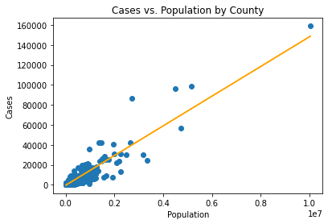

```
Predicted Cases = 0.01485946763960468 * Population + -386.309026582647
r2 score: 0.8589191223499983
p-value: 0.0
```

```python
# Model cases across population
X = pd.DataFrame(cc_current['population'])
y = pd.DataFrame(cc_current['cases'])
# Create linear regression model.
model = LinearRegression()
model.fit(X, y)
coef = model.coef_[0][0]
intercept = model.intercept_[0]
# Calculate p-value.A small p-value indicates strong evidence against the null hypothesis.
F = f_regression(X, y.values.ravel(), center=True)

# Create scatterplot of cases vs. population.
plt.scatter(cc_current['population'], cc_current['cases'])
plt.title('Cases vs. Population by County')
plt.xlabel('Population')
plt.ylabel('Cases')
# Plot regression line
plt.plot(cc_current['population'], coef * cc_current['population'] + intercept,  color='orange')
plt.show()
# Print fitted model.
print('Predicted Cases = ' + str(coef) + ' * Population + ' + str(intercept))
print('r2 score: ' + str(r2_score(y, model.predict(X))))
print('p-value: '+ str(F[1][0]))
```

The $p$-value is 0.0, which, as expected, is less than the accepted threshold of 0.05. Therefore, we reject the null hypothesis: there is a highly statistically significant relationship between the total number of COVID-19 cases in a county and its population.

The $r^2$ score is a high 0.859, indicating that the model is a good fit for the data. While this regression model has a much higher goodness of fit than the state model, most counties in the U.S. are not similar to Prince George County and College Park. Therefore, the dataset could be trimmed to provide more focused results and perhaps an even higher $r^2$ score.

## Modeling the Pandemic in Maryland

Our final model explores the relationship between total cases and population of counties in the state of Maryland. In a typical school year, the vast majority of students attending the University of Maryland who live off campus live in Maryland. Additionally, College Park and its immediate surroundings are most similar to other counties in Maryland.

The dataframe created for the previous model has the most current population, case count, and death count for all counties in the United States. We select only the 23 counties in the state of Maryland.

```python
# Create dataframe for Maryland's current data.
md_current = cc_current.loc[cc_current['state'] == 'Maryland']
md_current.reset_index(inplace=True,drop=True)

md_current
```

|  | county | state | population | cases | deaths |
| --- | --- | --- | --- | --- | --- |
| 0 | Allegany, Maryland | Maryland | 70416.0 | 239 | 18 |
| 1 | Anne Arundel, Maryland | Maryland | 579234.0 | 6011 | 213 |
| 2 | Baltimore city, Maryland | Maryland | 593490.0 | 9519 | 384 |
| 3 | Baltimore, Maryland | Maryland | 827370.0 | 9848 | 512 |
| 4 | Calvert, Maryland | Maryland | 92525.0 | 495 | 27 |
| 5 | Caroline, Maryland | Maryland | 33406.0 | 365 | 3 |
| 6 | Carroll, Maryland | Maryland | 168447.0 | 1279 | 116 |
| 7 | Cecil, Maryland | Maryland | 102855.0 | 560 | 29 |
| 8 | Charles, Maryland | Maryland | 163257.0 | 1621 | 90 |
| 9 | Dorchester, Maryland | Maryland | 31929.0 | 246 | 5 |
| 10 | Frederick, Maryland | Maryland | 259547.0 | 2746 | 120 |
| 11 | Garrett, Maryland | Maryland | 29014.0 | 34 | 0 |
| 12 | Harford, Maryland | Maryland | 255441.0 | 1430 | 66 |
| 13 | Howard, Maryland | Maryland | 325690.0 | 3134 | 98 |
| 14 | Kent, Maryland | Maryland | 19422.0 | 224 | 23 |
| 15 | Montgomery, Maryland | Maryland | 1050688.0 | 16471 | 772 |
| 16 | Prince George's, Maryland | Maryland | 909327.0 | 21150 | 724 |
| 17 | Queen Anne's, Maryland | Maryland | 50381.0 | 332 | 23 |
| 18 | Somerset, Maryland | Maryland | 25616.0 | 108 | 3 |
| 19 | Talbot, Maryland | Maryland | 37181.0 | 257 | 4 |
| 20 | Washington, Maryland | Maryland | 151049.0 | 796 | 29 |
| 21 | Wicomico, Maryland | Maryland | 103609.0 | 1189 | 42 |
| 22 | Worcester, Maryland | Maryland | 52276.0 | 418 | 18 |

We graph the total cases across total population for each U.S. county in a scatterplot to visualize the relationship between case count and population. The distribution appears to be roughly linear, so we also fit linear regression line using scikit learn and overlay it on the plot.

Scikit learn is also used to calculate the $p$-value of the distribution and $r^2$ score of the model. The null hypothesis of the significance test is that there is no statistically significant relationship between the total number of COVID-19 cases in a county and its population.

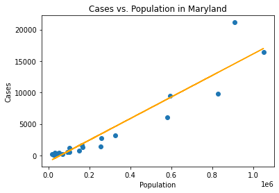

```
Predicted Cases = 0.017140366774711403 * Population + -1009.0247639104241
r2 score: 0.8941283325149617
p-value: 1.0421718301217267e-11
```

```python
# Model cases across population
X = pd.DataFrame(md_current['population'])
y = pd.DataFrame(md_current['cases'])
# Create linear regression model.
model = LinearRegression()
model.fit(X, y)
coef = model.coef_[0][0]
intercept = model.intercept_[0]
# Calculate p-value.A small p-value indicates strong evidence against the null hypothesis.
F = f_regression(X, y.values.ravel(), center=True)

# Create scatterplot of cases vs. population.
plt.scatter(md_current['population'], md_current['cases'])
plt.title('Cases vs. Population in Maryland')
plt.xlabel('Population')
plt.ylabel('Cases')
# Plot regression line
plt.plot(md_current['population'], coef * md_current['population'] + intercept,  color='orange')
plt.show()
# Print fitted model.
print('Predicted Cases = ' + str(coef) + ' * Population + ' + str(intercept))
print('r2 score: ' + str(r2_score(y, model.predict(X))))
print('p-value: '+ str(F[1][0]))
```

The $r^2$ score is 0.894, which means that this model has even better goodness of fit than the U.S. counties model. Along with the aforementioned reasons, this means that this model will output predictions most representative of the data. Therefore, we will use this model in our insight and policy decision discussion.

The model predicts that 0.017 people in a county will be infected by the coronavirus for every additional person in the population. As expected, the $p$-value is below 0.05; there is a statistically significant relationship between total cases and population for counties in Maryland.

## Insights Regarding the University of Maryland

What does this information mean for the University of Maryland? As illustrated by the Total Cases vs. Time line chart, coronavirus case counts in the United States are climbing more rapidly than ever. This steep trend is projected to continue past the beginning of the fall semester on August 31. The [official facts and figures](https://research.umd.edu/about/facts-figures) published by the Division of Research state that 41,000 students are enrolled at College Park.

According to this report by the [U.S. News](https://www.usnews.com/best-colleges/university-of-maryland-2103/student-life#:~:text=University%20of%20Maryland%2D%2DCollege%20Park%20has%20a%20total%20undergraduate,of%20students%20live%20off%20campus.), 41% of University of Maryland, College Park students live in college-owned, -operated or -affiliated housing during a typical school year. We could not find any official figures for the proportion of students living off campus that move to College Park only for the school year, so we base our predictions only on the students that move into university housing.

```python
# Estimate number of students that move into university housing.
students = 41000 * 0.41
print('Students in University Housing: ' + str(students))
# Calculate number of cases predicted by the model.
print('Predicted Cases: ' + str(coef * students))
```

```
Students in University Housing: 16810.0
Predicted Cases: 288.12956548289867
```

If university housing was filled to normal capacity, the population of College Park would increase by approximately 16,810 people. The linear regression model, fitted to the total cases across population of counties in Maryland, estimates that 288 coronavirus cases would be reported.

This figure is almost definitely an underestimate: the coefficient and, as a result, the predicted cases will most likely continue to grow as the virus continues to spread. University housing can also be very different than regular residences. The [UMD Student Housing Market Analysis](http://reslife.umd.edu/global/documents/marketreport/UMDStudentHousingMarketAnalysis2017Report.pdf) writes that 57% of units are doubles and 12% are triples. Dormitory rooms with two or even three students would spread the virus quickly, especially since the university has an unfortunate history with [viruses spreading in residence halls](https://www.washingtonpost.com/news/national/wp/2019/05/16/feature/university-of-maryland-mold-adenovirus/).

Furthermore, this prediction only accounts for changes in housing. In-person lectures and discussion put potentially hundreds of students in close proximity with each other for prolonged periods of time. Of course, the very nature of college students -- and their social lives -- is also very vulnerable to pandemics. Student life and bars will pose major health threats.

```python
# Possible faculty member deaths.
print('Deaths: ' + str(death_rate * coef * 14000))
```

```
Deaths: 8.78279710661456
```

While college-aged students are unlikely to die from complications caused by the coronavirus, faculty and staff members tend to be older and more susceptible to the virus. The [official facts and figures](https://research.umd.edu/about/facts-figures) state that 14,000 faculty and staff members are employed at College Park. The figure above uses the national death rate to predict the number of faculty and staff that could succumb to COVID-19.

It is in no way an accurate estimate, but the figure represents how an ordinary semester in the current environment would be dangerous.

## Policy Decisions for the 2020-2021 School Year

Fortunately, the University of Maryland is already taking steps. The decision to close the campus after spring break in 2020 prevented many students from contracting the virus. UMD's [Fall 2020 Reopening plan](https://umd.edu/4Maryland) focuses on minimizing in-person social interactions and providing a safe and healthy on-campus learning environment. Most classes are online only, personal protective equipment is required, and students have the opportunity to stay at home for the semester. Dining halls have strategies to avoid large gatherings of people and the contamination of food. Research, clubs, and fraternities must adhere to the community safety guidelines. The Health, Counseling, and Career centers will remain open for appointments.

The residence halls section of the [Student Life Plan](https://umd.edu/4Maryland/student-life-plan) is most relevant to our insight discussion. Residence halls have been converted to reduce occupancy and increase distance. The deadline to cancel agreements has also been extended, allowing more students to choose not to return to campus without wasting money on an unoccupied room. Students will have the opportunity to apply for housing for the spring semester if the campus reopens. No statistics have been published, but the changes are critical in preventing COVID-19 from surging in university residences.

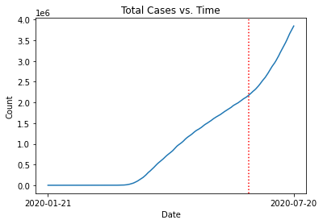

```python
# Plot cases on a line chart.
cases = covid.groupby('date', as_index=False)[['cases']].sum()
plt.plot(cases['date'], cases['cases'], label='Cases')
plt.title('Total Cases vs. Time')
plt.xlabel('Date')
plt.xticks([covid.date.min(), covid.date.max()])
plt.ylabel('Count')
# Overlay line to show the effects of reopening too early.
plt.axvline(x='2020-06-17', color='red', linestyle=':')
plt.show()
```

However, there are weaknesses in the plan. Eppley Recreation Center and the Stamp Student Union will both be open and will even provide in-person activities. Although both facilities are normally vital to student life and physical well-being, keeping gyms open and encouraging in-person social gatherings during a pandemic is considered by some to be irresponsible. Closing these facilities and cancelling in-person events is the safer option. The continued operation of businesses outside of the University's control, such as bars and fraternities, could also contribute to the pandemic, but these are issues better handled by local governments.

Decisions to reopen the campus must be made very carefully. The red dotted line in the Total Cases vs. Time plot depicts a previously made observation that new virus cases per day more than doubled when governments attempted to lift restrictions on their communities. Reopening too early could be disastrous, especially since out of state and international students make up [24.3% of the undergraduate population](https://research.umd.edu/about/facts-figures). New cases must be at a minimum not only in Maryland, but also the entire United States and even the world before it is safe to reopen.

The University of Maryland has adapted to these insights. According to the [original plan](https://president.umd.edu/articles/fall-2020-update#:~:text=We%20will%20begin%20the%20fall,the%20pandemic%20in%20late%20fall.) sent out by email on June 15, the University of Maryland initially planned to begin the fall semester as scheduled and move to online instruction after Thanksgiving break if the pandemic had a resurgence in the fall. Since then, the University has made the decision to conduct the entire fall semester remotely.

Whether to resume in-person instruction in January has yet to be decided. We would advise the University of Maryland to continue remote instruction throughout the spring semester based on the results of our analysis. The current upward trend in cases indicates that the pandemic is unlikely to be sufficiently subdued in time and reopening the campus would be hazardous to students, faculty, and staff.

## References

1. Abelson, Jenn, et al. “Adenovirus at the University of Maryland.” The Washington Post, WP Company, 16 May 2019, www.washingtonpost.com/news/national/wp/2019/05/16/feature/university-of-maryland-mold-adenovirus/.
2. Bureau, US Census. “County Population Totals: 2010-2019.” The United States Census Bureau, The United States Census Bureau, 22 June 2020, www.census.gov/data/datasets/time-series/demo/popest/2010s-counties-total.html.
3. “Coronavirus (Covid-19) Data in the United States.” New York Times Github, New York Times, 21 July 2020, www.github.com/nytimes/covid-19-data.
4. Drl. “Student Housing Market Analysis.” Department of Resident Life, University of Maryland, June 2017, www.reslife.umd.edu/marketstudy/.
5. Facts and Figures, Division of Research, Aug. 2019, www.research.umd.edu/about/facts-figures.
6. “Fall 2020 Reopening Plan.” University of Maryland, University of Maryland, 16 July 2020, www.umd.edu/4Maryland.
7. “Here's What Student Life Is Like At University of Maryland--College Park.” U.S. News & World Report, U.S. News & World Report, www.usnews.com/best-colleges/university-of-maryland-2103/student-life.
8. Loh, Wallace D. “Fall 2020 Update.” Office of the President, University of Maryland, 15 June 2020, www.president.umd.edu/articles/fall-2020-update.
9. “State Population by Rank.” Infoplease, Infoplease, June 2019, www.infoplease.com/us/states/state-population-by-rank.

```python
%%capture
# Export notebook as index.html
os.remove("index.html")
! jupyter nbconvert index.ipynb
```